# Take Home Final Exam

For the take-home part of the MSDS 401 Final Exam, you are tasked with analyzing data on new daily covid-19 cases and deaths in European Union (EU) and European Economic Area (EEA) countries. A data file may be downloaded [here](https://www.ecdc.europa.eu/en/publications-data/data-daily-new-cases-covid-19-eueea-country), *or* you may use the provided **read.csv()** code in the 'setup' code chunk below to read the data directly from the web csv. Either approach is acceptable; the data should be the same.

Once you have defined a data frame with the daily case and death and country data, you are asked to: (1) perform an Exploratory Data Analysis (EDA), (2) perform some hypothesis testing, (3) perform some correlation testing, and (4) fit and describe a linear regression model. Each of these four (4) items is further explained below and "code chunks" have been created for you in which to add your R code, just as with the R and Data Analysis Assignments. You may add additional code chunks, as needed. You should make comments in the code chunks or add clarifying text between code chunks that you think further your work.

A data dictionary for the dataset is available [here](https://www.ecdc.europa.eu/sites/default/files/documents/Description-and-disclaimer_daily_reporting.pdf).

#### Definitions:

- "Incidence rate" is equal to new daily cases per 100K individuals. Country population estimates can be found in 'popData2020.' You will calculate a daily incidence rate in item (1), for each country, that we will explore further in items (2) and (3).
- "Fatality rate" is equal to new daily deaths per 100K individuals. Country population estimates can be found in 'popData2020.' You will calculate a daily fatality rate in item (1), for each country, that we will explore further in items (2) and (3).

#### 1. Descriptive Statistics

Perform an Exploratory Data Analysis (EDA). Your EDA is exactly that: yours. Your knit .html should include the visualizations and summary tables that you find valuable while exploring this dataset. **However**, at minimum, your EDA must include the following:

- Creation of a vector, 'incidence_rate,' equal to the daily new cases per 100K individuals, per country. Country populations are provided in 'popData2020.' This vector should be added to the 'data' data frame.
- Creation of a vector, 'fatality_rate,' equal to the new deaths per 100K individuals, per country. Country populations are provided in 'popData2020.' This vector should be added to the 'data' data frame.
- A visualization exploring new cases or incidence rates, per country, over time. You may choose a subset of countries, if you wish, but your visualization should include at least five (5) countries and include the entire time frame of the dataset.
- A visualization exploring new deaths or fatality rates, per country, over time. You may choose a subset of countries, if you wish, but your visualization should include at least five (5) countries.
- A table or visualization exploring some other aspect of the data. For example, you could explore case fatality rates per country; the number of deaths divided by the total number of cases. Note that to do this, you would want to like across the entire time of the dataset, looking at the total cases and deaths, per country.

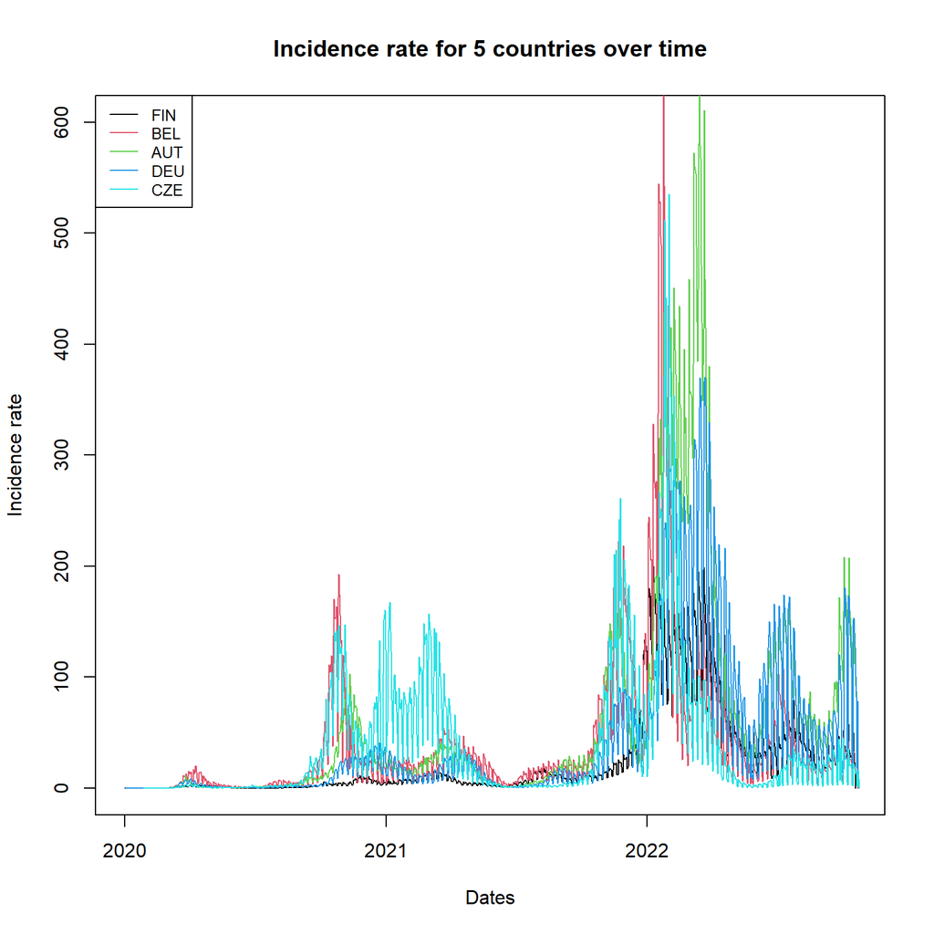

```r
data$incidence_rate <- (data$cases/data$popData2020) * 100000
#data$incidence_rate
data$fatality_rate <- (data$deaths/data$popData2020) * 100000
#data$fatality_rate



#Incidence
plot(data$dateRep[data$countryterritoryCode == "FIN"], data$incidence_rate[data$countryterritoryCode == "FIN"], type = "l", col = 1, main = "Incidence rate for 5 countries over time", ylim = c(0, 600), xlab = "Dates", ylab = "Incidence rate")
lines(data$dateRep[data$countryterritoryCode == "BEL"], data$incidence_rate[data$countryterritoryCode == "BEL"], type = "l", col = 2)
lines(data$dateRep[data$countryterritoryCode == "AUT"], data$incidence_rate[data$countryterritoryCode == "AUT"], type = "l", col = 3)
lines(data$dateRep[data$countryterritoryCode == "DEU"], data$incidence_rate[data$countryterritoryCode == "DEU"], type = "l", col = 4)
lines(data$dateRep[data$countryterritoryCode == "CZE"], data$incidence_rate[data$countryterritoryCode == "CZE"], type = "l", col = 5)
legend(x = "topleft", legend = c("FIN", "BEL", "AUT", "DEU", "CZE"), col = 1:5, lty = 1, cex = 0.8)
```

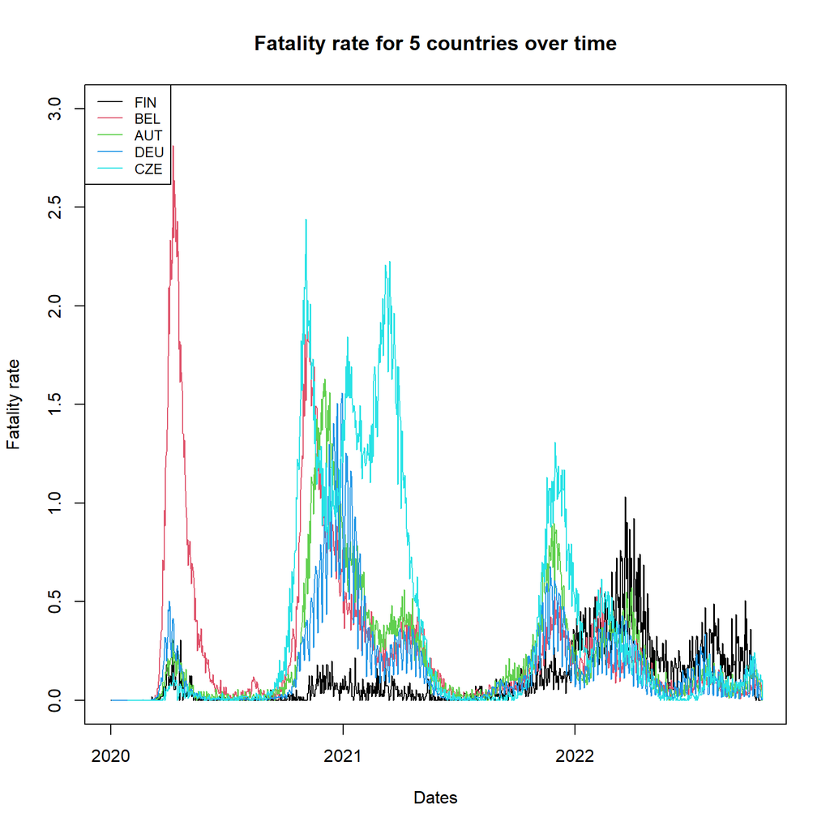

```r
#Fatality
plot(data$dateRep[data$countryterritoryCode == "FIN"], data$fatality_rate[data$countryterritoryCode == "FIN"], type = "l", col = 1, main = "Fatality rate for 5 countries over time", ylim = c(0, 3), xlab = "Dates", ylab = "Fatality rate")
lines(data$dateRep[data$countryterritoryCode == "BEL"], data$fatality_rate[data$countryterritoryCode == "BEL"], type = "l", col = 2)
lines(data$dateRep[data$countryterritoryCode == "AUT"], data$fatality_rate[data$countryterritoryCode == "AUT"], type = "l", col = 3)
lines(data$dateRep[data$countryterritoryCode == "DEU"], data$fatality_rate[data$countryterritoryCode == "DEU"], type = "l", col = 4)
lines(data$dateRep[data$countryterritoryCode == "CZE"], data$fatality_rate[data$countryterritoryCode == "CZE"], type = "l", col = 5)
legend(x = "topleft", legend = c("FIN", "BEL", "AUT", "DEU", "CZE"), col = 1:5, lty = 1, cex = 0.8)
```

```r
#Looking at case fatality rate, total per country over the time span
country_total <- data %>% group_by(countryterritoryCode) %>% summarise(fatal_rate = sum(na.omit(deaths))/sum(na.omit(cases)))
country_total[order(country_total$fatal_rate, decreasing = TRUE),]
```

```
## # A tibble: 30 x 2
##    countryterritoryCode fatal_rate
##    <fct>                     <dbl>
##  1 BGR                     0.0296
##  2 HUN                     0.0224
##  3 ROU                     0.0207
##  4 POL                     0.0191
##  5 HRV                     0.0137
##  6 CZE                     0.0100
##  7 ESP                     0.00841
##  8 SVK                     0.00809
##  9 SWE                     0.00783
## 10 ITA                     0.00765
## # i 20 more rows
```

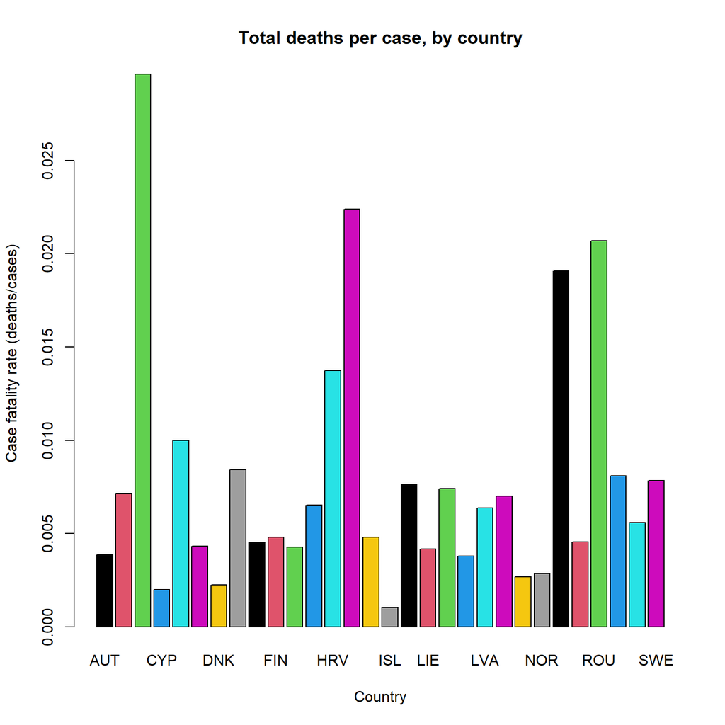

```r
barplot(country_total$fatal_rate ~ country_total$countryterritoryCode, col = country_total$countryterritoryCode, main = "Total deaths per case, by country", xlab = "Country", ylab = "Case fatality rate (deaths/cases)")
```